# in vitro CLIP analysis

Mario Keller

Faculty of Biological Sciences, Goethe University Frankfurt

22 June 2023

```r
library(tidyverse)
library(knitr)
library(ggExtra)
library(ggpubr)
library(rstatix)
library(ggbeeswarm)
library(ggrastr)
library(DESeq2)
```

```r
myTheme <- theme_bw() +
    theme(axis.text = element_text(size = 14, colour="black"),
          axis.title = element_text(size=16, colour="black"),
          axis.ticks=element_line(color="black"),
          axis.ticks.length=unit(.15, "cm"),
          panel.border=element_rect(color="black", fill = NA),
          panel.background = element_blank(),
          plot.background = element_blank(),
          legend.text = element_text(size=12),
          legend.position = "none")
```

```r
projectDir <- "/Users/mariokeller/projects/HNRNPH_project/Tretow_et_al_2023"

dataDir <- paste0(projectDir, "/data")
iClipDir <- paste0(projectDir, "/4_iCLIP_analysis")
RTstopDir <- paste0(projectDir, "/6_RTstop_profiling")
```

# 1 Background

Based on the RTstop profiling classification results, the binding in vitro binding of HNRNPH to rG4 and non-rG4 containing constructs should be analyzed.

# 2 Data

ivCLIP and RTstop counts per construct and condition are loaded from RDS-Files. For the RTstop profiling only KCl experiments were considered.

In addition, constructClassification.rds is loaded. In addition, all the rG4 peaks of rG4 classified constructs are loaded to calculate the so-called “G4 propensity” of the constructs, which is summed up signal of the rG4 peaks of a construct.

```r
ivCLIP <- readRDS(paste0(dataDir,
                         "/in_vitro_CLIP/invitroCLIP_March_2021.l.rds"))

RTstop <- readRDS(paste0(dataDir,
                         "/RTstop_profiling/RTstop.profiling.l.rds"))
RTstop <- RTstop[c(1:3, 7:9)]

constructClassification <- readRDS(paste0(dataDir,
                         "/RTstop_profiling/constructClassification.rds"))

constructInformation <- readRDS(paste0(dataDir,
                         "/RTstop_profiling/constructInformation.rds"))

allG4peaks <- readRDS(paste0(dataDir,
                         "/RTstop_profiling/AllG4Peaks.rds"))
```

Here is an overview about the samples:

```r
data.frame(Experiment = c(rep("ivCLIP", length(ivCLIP)),
                        rep("RTstop", length(RTstop))),
           Nucleotide = c(names(ivCLIP) %>% strsplit(., "_", fixed=T) %>% sapply(.,"[[",1),
                          names(RTstop) %>% strsplit(., "_", fixed=T) %>% sapply(.,"[[",1)),
           Replicate = c(names(ivCLIP) %>% strsplit(., "_", fixed=T) %>% sapply(.,"[[",2),
                          names(RTstop) %>% strsplit(., "_", fixed=T) %>% sapply(.,"[[",3))) %>%
    kable(., "html", align="c") %>%
    kableExtra::kable_styling("striped") %>%
    kableExtra::scroll_box(height="100%", width = "94%")
```

| Experiment | Nucleotide | Replicate |
| --- | --- | --- |
| ivCLIP | GTP | rep1 |
| ivCLIP | GTP | rep2 |
| ivCLIP | GTP | rep3 |
| ivCLIP | GTP | rep4 |
| ivCLIP | 7dGTP | rep1 |
| ivCLIP | 7dGTP | rep2 |
| ivCLIP | 7dGTP | rep3 |
| ivCLIP | 7dGTP | rep4 |
| RTstop | GTP | rep1 |
| RTstop | GTP | rep2 |
| RTstop | GTP | rep3 |
| RTstop | 7dGTP | rep1 |
| RTstop | 7dGTP | rep2 |
| RTstop | 7dGTP | rep3 |

```r
rG4propensity <- allG4peaks %>%
    as.data.frame %>%
    group_by(seqnames) %>%
    summarise(rG4propensity = sum(xlinksKCL_ratio)) %>%
    dplyr::rename(ID=seqnames)
```

# 3 Pre-processing

## 3.1 Creating read counts

Construct readCounts for the ivCLIP and RTstop profiling experiments were computed as the sum across the 200 nts.

```r
ivCLIP_rc <-  lapply(ivCLIP, sum) %>%
    bind_cols() %>%
    as.data.frame %>%
    mutate(ID=names(ivCLIP$GTP_rep1)) # %>%

RTstop_rc <- lapply(RTstop, sum) %>%
    bind_cols() %>%
    as.data.frame %>%
    mutate(ID=names(RTstop$GTP_KCL_rep1))
```

## 3.2 Normalization by DESeq2

For both ivCLIP and RTstop dds objects were created, followed by estimation of size factors and log2 transformation of normalized counts by the normTransform() function. For the RTstop profiling size factors were estimated based on all constructs, whereas for the ivCLIP Spike-Ins with a mean read count $\ge$ 100 were used.

```r
ivCLIP_dds <- DESeqDataSetFromMatrix(
    countData = ivCLIP_rc[,1:8],
    colData = data.frame(
        condition=colnames(ivCLIP_rc)[1:8] %>%
            strsplit("_", fixed=T) %>%
            sapply("[[", 1),
        rep=colnames(ivCLIP_rc)[1:8] %>%
            strsplit("_", fixed=T) %>%
            sapply("[[", 2)),
    design = ~ condition)

RTstop_dds <- DESeqDataSetFromMatrix(
    countData = RTstop_rc[,1:6],
    colData = data.frame(
        condition=colnames(RTstop_rc)[1:6] %>%
            strsplit("_", fixed=T) %>% sapply("[[", 3),
        rep=colnames(RTstop_rc)[1:6] %>%
            strsplit("_", fixed=T) %>%
            sapply("[[", 3)),
    design = ~ condition)

ivCLIP_dds <- estimateSizeFactors(
    ivCLIP_dds,
    controlGenes = names(which(ivCLIP_rc[12001:12010,1:8] %>%
                                   rowMeans() >= 100)) %>%
        as.numeric())

RTstop_dds <- estimateSizeFactors(
    RTstop_dds)

ivCLIP_log2 <- normTransform(ivCLIP_dds) %>%
    assay %>%
    as.data.frame %>%
    cbind(., ID=ivCLIP_rc$ID)

RTstop_log2 <- normTransform(RTstop_dds) %>%
    assay %>%
    as.data.frame %>%
    cbind(., ID=RTstop_rc$ID)

 #  GTP_rep1   GTP_rep2   GTP_rep3   GTP_rep4 7dGTP_rep1 7dGTP_rep2 7dGTP_rep3 7dGTP_rep4
 # 1.0924278  1.5627571  1.4357800  1.2228067  0.4278978  0.7560091  0.9555820  1.3209018
```

For the upcoming analyses, I remove the Spike-Ins from the data.frame.

```r
ivCLIP_log2 <- ivCLIP_log2[1:12000,]
```

## 3.3 Merging of replicates

Replicates of the RTstop profiling and the ivCLIP are merged by computing the mean of normalized and log2-transformed counts.

```r
ivCLIP_log2 <- ivCLIP_log2 %>%
    mutate(merge_ivCLIP_GTP=rowMeans(across(starts_with("GTP")))) %>%
    mutate(merge_ivCLIP_7dGTP=rowMeans(across(starts_with("7dGTP"))))

RTstop_log2 <- RTstop_log2 %>%
    mutate(merge_RTstop_GTP=rowMeans(across(starts_with("GTP")))) %>%
    mutate(merge_RTstop_7dGTP=rowMeans(across(starts_with("7dGTP"))))
```

## 3.4 Combining the experiments

The merged values of the RTstop profiling and ivCLIP were combined in a single data.frame.

```r
# Note that I checked the order:
# > identical(ivCLIP_log2$ID, RTstop_log2$ID)
# [1] TRUE

Combined <- left_join(RTstop_log2 %>%
                                   dplyr::select(ID,
                                                 merge_RTstop_GTP,
                                                 merge_RTstop_7dGTP),
                               ivCLIP_log2 %>%
                                   dplyr::select(ID,
                                                 merge_ivCLIP_GTP,
                                                 merge_ivCLIP_7dGTP))
```

In addition, for GTP and 7dGTP samples a normalized HNRNPH binding strength is computed as $ivCLIP_{log2} - RTstop_{log2}$. The idea of this step is to normalize the binding signal to the expression strength of the constructs, which is estimated from the RTstop profiling.

```r
Combined$normalizedBindingStrengthGTP <- Combined$merge_ivCLIP_GTP - Combined$merge_RTstop_GTP
Combined$normalizedBindingStrength7dGTP <- Combined$merge_ivCLIP_7dGTP - Combined$merge_RTstop_7dGTP
```

## 3.5 Annotating with G4 and non-G4 information

As the final pre-processing step, the construct classification (rG4 / non-rG4) from the RTstop profiling is used to annotate the constructs. All constructs not classified are removed immediately, resulting in 2,169 constructs. In addition, the rG4propensity values are added to constructs classified as “rG4”.

```r
Combined <- left_join(
    Combined,
    constructClassification %>%
        dplyr::select(Construct.ID, regulationGroup,
                      strongestPeakStrengthRatio, constructStrengthRatio) %>%
        dplyr::rename(ID=Construct.ID, anno=regulationGroup)) %>%
    na.omit() %>%
    mutate(anno = ifelse(anno == "G4","rG4","non-rG4")) %>%
    remove_rownames() %>%
    mutate(anno=factor(anno, levels=c("rG4", "non-rG4")))

Combined <- left_join(Combined, rG4propensity)
```

[output not shown]

# 4 Correlation RTstop and ivCLIP

To analyze HNRNPH1 binding but also consider the expression strength of the constructs (approximated by RTstop profiling) ivCLIP and RTstop profiling log2 values are plotted against each other for GTP and 7dGTP experiments.

### 4.0.1 GTP

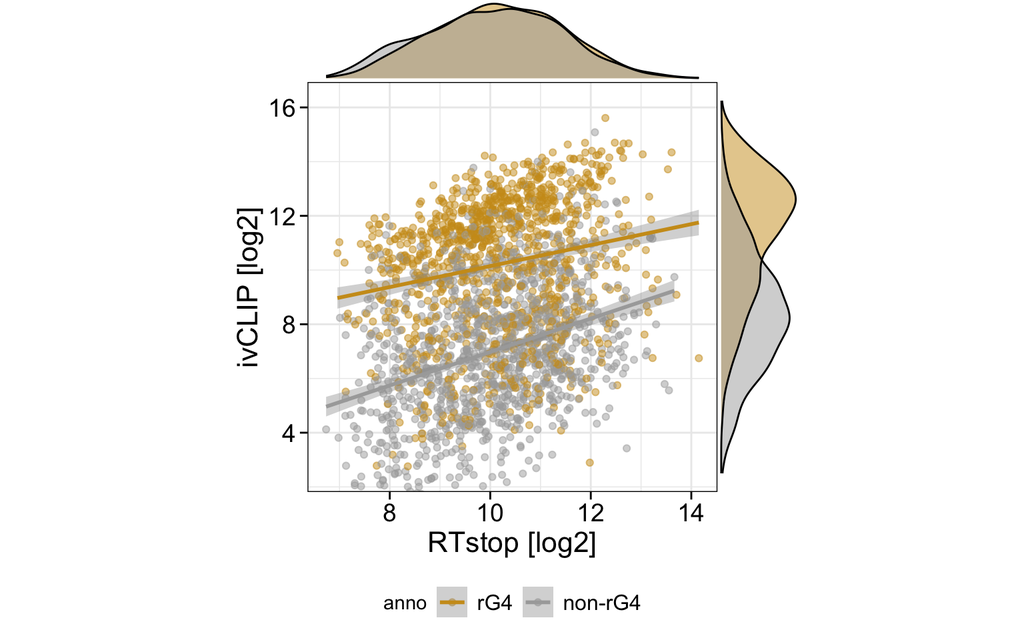

```r
ggMarginal(
    ggplot(Combined, aes(x=merge_RTstop_GTP, y=merge_ivCLIP_GTP, col=anno)) +
        geom_point(alpha=.5) +
        scale_color_manual(values=c("rG4" = "goldenrod3",
                                    "non-rG4" = "darkgrey")) +
        geom_smooth(method="lm") +
        coord_cartesian(ylim=c(2.5,16.25)) +
        labs(x="RTstop [log2]", y="ivCLIP [log2]") +
        myTheme +
        theme(aspect.ratio = 1/1, legend.position = "bottom"),
type="density", groupFill=TRUE
)
```

### 4.0.2 7dGTP

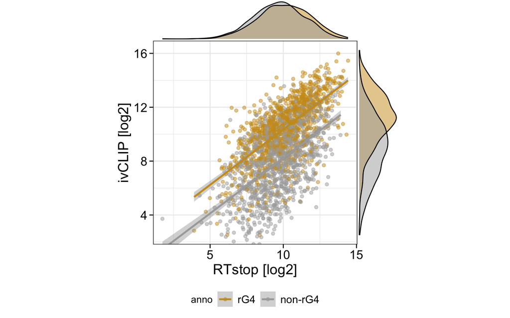

```r
ggMarginal(
    ggplot(Combined, aes(x=merge_RTstop_7dGTP, y=merge_ivCLIP_7dGTP, col=anno)) +
        geom_point(alpha=.5) +
        scale_color_manual(values=c("rG4" = "goldenrod3",
                                    "non-rG4" = "darkgrey")) +
        geom_smooth(method="lm") +
        coord_cartesian(ylim=c(2.5,16.25)) +
        labs(x="RTstop [log2]", y="ivCLIP [log2]") +
        myTheme +
        theme(aspect.ratio = 1/1, legend.position = "bottom"),
type="density", groupFill=TRUE
)
```

I also performed a statistical test for GTP and 7dGTP, where I test for a difference in binding between rG4 and non-rG4 constructs.

Here is the P value of the Wilcoxon test for the GTP condition:

```r
res_1 <- wilcox.test(Combined %>% dplyr::filter(anno=="rG4") %>% pull(normalizedBindingStrengthGTP),
                     Combined %>% dplyr::filter(anno=="non-rG4") %>% pull(normalizedBindingStrengthGTP))

res_1$p.value
```

```
## [1] 1.90231e-135
```

Here is the P value of the Wilcoxon test for the 7dGTP condition:

```r
res_2 <- wilcox.test(Combined %>% dplyr::filter(anno=="rG4") %>% pull(normalizedBindingStrength7dGTP),
                     Combined %>% dplyr::filter(anno=="non-rG4") %>% pull(normalizedBindingStrength7dGTP))

res_2$p.value
```

```
## [1] 2.775791e-115
```

# 5 Dependence of HNRNPH1 binding on rG4 propensity

To check whether the propensity to form rG4s plays a role in the binding of HNRNPH1 to rG4 constructs, the rG4 constructs were binned by rG4 propensity and the enrichment (ivCLIP - RTstop) plotted.

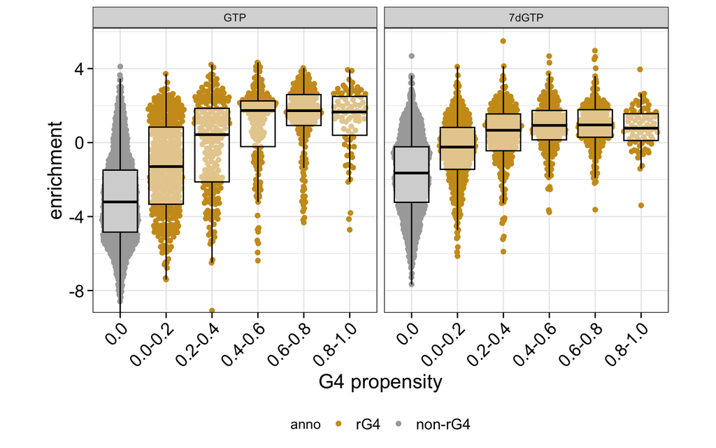

```r
plotDF <- Combined %>%
    dplyr::mutate(rG4propensity = ifelse(anno == "rG4", rG4propensity, 0)) %>%
    mutate(bin=cut(rG4propensity, breaks=c(-1, 0, 0.2, 0.4, 0.6, 0.8, 1),
                   labels = c("0.0", "0.0-0.2", "0.2-0.4", "0.4-0.6",
                              "0.6-0.8", "0.8-1.0"))) %>%
    pivot_longer(., cols=c("normalizedBindingStrengthGTP", "normalizedBindingStrength7dGTP"),
                 names_to="facet", values_to="enrichment") %>%
    mutate(facet=factor(ifelse(facet == "normalizedBindingStrengthGTP", "GTP", "7dGTP"),
                        levels=c("GTP", "7dGTP")))

plotDF %>%
    ggplot(., aes(x=bin, y=enrichment, col=anno)) +
        geom_quasirandom() +
        geom_boxplot(alpha=.5, outlier.size = -1, col="black", position = position_dodge(width = 0.9)) +
        scale_color_manual(values=c("rG4" = "goldenrod3",
                                "non-rG4" = "darkgrey")) +
        scale_y_continuous(breaks=seq(-8, 8, 4)) +
        coord_cartesian(ylim=c(-8.5, 5.5)) +
        facet_wrap(~facet) +
        labs(x="G4 propensity") +
        myTheme +
        theme(aspect.ratio=1/1,
              axis.text.x = element_text(angle = 45, vjust = 1, hjust=1),
              legend.position = "bottom")
```

# 6 Dependence of HNRNPH1 binding on rG4 propensity considering G-triplets

As there might be differences due to differences in number of G-triplets between the bins, I also grouped constructs based on the amount of G-triplets they contain and use this information for facet wrapping.

```r
library(Biostrings)

Combined <- left_join(
    Combined,
    constructInformation %>% select(ID = Construct.ID, Seq) %>% mutate(ID = as.character(ID))
)

dss <- DNAStringSet(Combined$Seq)
G_triplet_hits <- vmatchPattern("GGG", dss)
G_triplet_hits <- lapply(G_triplet_hits, function(ir)reduce(ir))
G_triplet_hits <- lapply(G_triplet_hits, function(ir)width(ir) %/% 3)
G_triplet_hits <- sapply(G_triplet_hits, function(v)sum(v))
Combined$G_triplets <- G_triplet_hits


# Combined$Gs_in_seq <- str_count(Combined$Seq, "G")

plotDF <- Combined %>%
    dplyr::mutate(rG4propensity = ifelse(anno == "rG4", rG4propensity, 0)) %>%
    mutate(facet=cut(G_triplets, breaks=c(-Inf, 2, 4, 6, Inf),
                   labels = c("<=2", "3/4", "5/6", ">6"))) %>%
    mutate(bin=cut(rG4propensity, breaks=c(-1, 0, 0.2, 0.4, 0.6, 0.8, 1),
                   labels = c("0.0", "0.0-0.2", "0.2-0.4", "0.4-0.6",
                              "0.6-0.8", "0.8-1.0")))
```

## 6.1 GTP

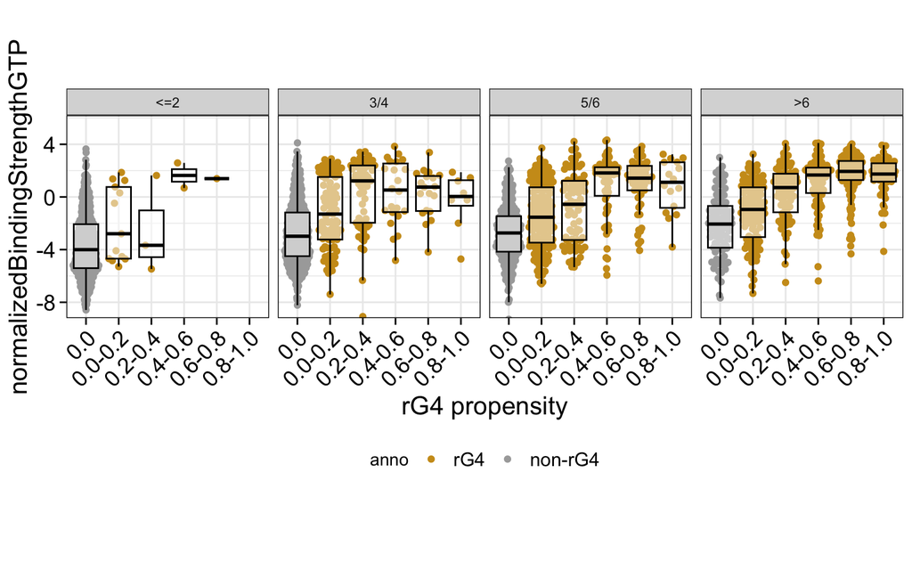

```r
plotDF %>%
    ggplot(., aes(x=bin, y=normalizedBindingStrengthGTP, col=anno)) +
        geom_quasirandom() +
        geom_boxplot(alpha=.5, outlier.size = -1, col="black", position = position_dodge(width = 0.9)) +
        scale_color_manual(values=c("rG4" = "goldenrod3",
                                "non-rG4" = "darkgrey")) +
        scale_y_continuous(breaks=seq(-8, 8, 4)) +
        coord_cartesian(ylim=c(-8.5, 5.5)) +
        facet_wrap(~facet, ncol=4, nrow=1) +
        labs(x="rG4 propensity") +
        myTheme +
        theme(aspect.ratio=1/1,
              axis.text.x = element_text(angle = 45, vjust = 1, hjust=1),
              legend.position = "bottom")
```

## 6.2 7dGTP

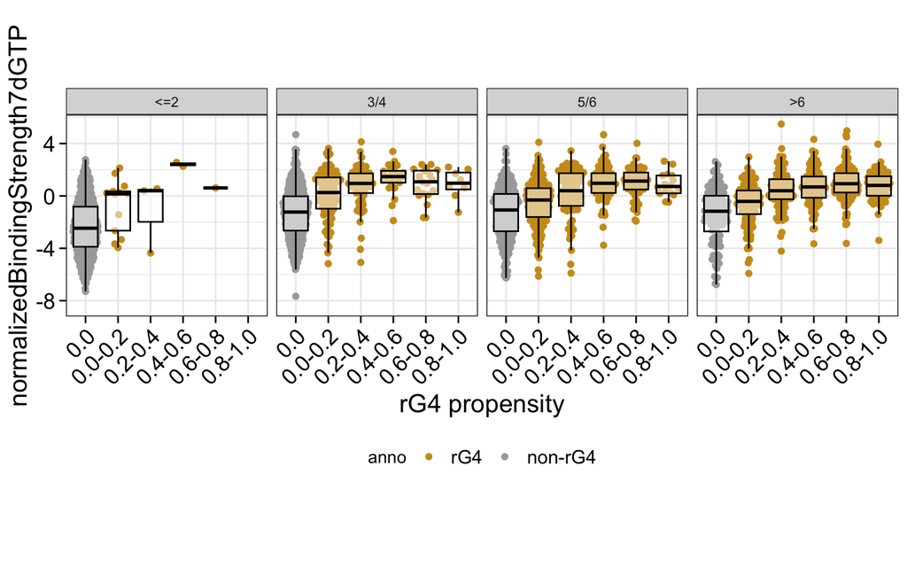

```r
plotDF %>%
    ggplot(., aes(x=bin, y=normalizedBindingStrength7dGTP, col=anno)) +
        geom_quasirandom() +
        geom_boxplot(alpha=.5, outlier.size = -1, col="black", position = position_dodge(width = 0.9)) +
        scale_color_manual(values=c("rG4" = "goldenrod3",
                                "non-rG4" = "darkgrey")) +
        scale_y_continuous(breaks=seq(-8, 8, 4)) +
        coord_cartesian(ylim=c(-8.5, 5.5)) +
        facet_wrap(~facet, ncol=4, nrow=1) +
        labs(x="rG4 propensity") +
        myTheme +
        theme(aspect.ratio=1/1,
              axis.text.x = element_text(angle = 45, vjust = 1, hjust=1),
              legend.position = "bottom")
```

# 7 Binding strength differences between GTP and 7dGTP for rG4 constructs

The final question was whether certain constructs show a stronger enrichment under GTP than under 7dGTP and whether this is related to a higher G4 propensity.

For this purpose, binding strength under GTP and 7dGTP are plotted against each other and points colored by rG4 propensity.

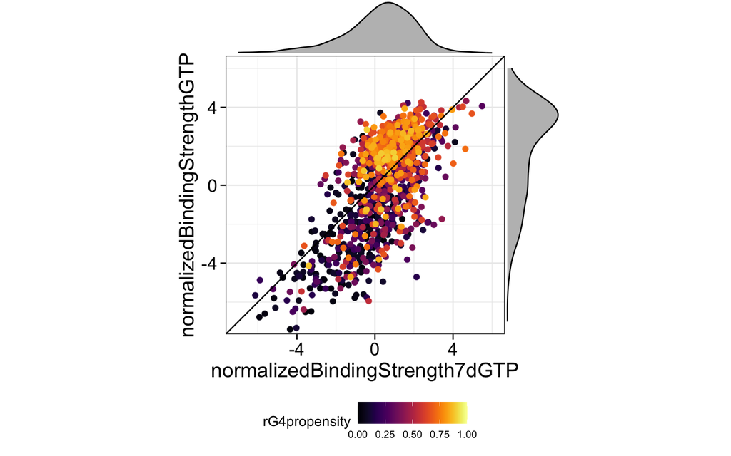

```r
ggMarginal(
    ggplot(Combined %>%
               dplyr::filter(anno=="rG4") %>%
               dplyr::arrange(rG4propensity), aes(x=normalizedBindingStrength7dGTP, y=normalizedBindingStrengthGTP, col=rG4propensity)) +
        rasterise(geom_point(alpha=1), dpi=300) +
        viridis::scale_color_viridis(option="B", breaks = seq(0,1,.25), limits=c(0,1)) +
        #geom_smooth(method="lm") +
        geom_abline(slope=1, intercept=0) +
        coord_cartesian(xlim=c(-7,6), ylim=c(-7,6)) +
        myTheme +
        theme(aspect.ratio = 1/1, legend.position = "bottom", legend.text = element_text(size=8)),
type="density", fill="grey"
)
```

# 8 Binding strength comparison with respect to RTstop profiling and rG4 prediction results

In *Comparison_RTstop_profiling_and_predictions.html* rG4s were predicted for rG4 and non-rG4 constructs and the agreement between the RTstop profiling classification and the in silico predictions analyzed. Based on this analysis we observed that for instance ~25% of non-rG4 constructs were predicted to actually contain an rG4. To check if this is true, we want to incorporate the in vitro binding strength based on the assumption that HNRNPH1 favors binding to folded rG4s. For this purpose, we create the following four sets:

- Measured rG4 and predicted rG4 (rG4_pos)
- Measured rG4 and no predicted rG4 (rG4_neg)
- No measured rG4 and predicted rG4 (non-rG4_pos)
- No measured rG4 and no predicted rG4 (non-rG4_neg)

For the four sets I create binding strength plots for GTP and 7dGTP.

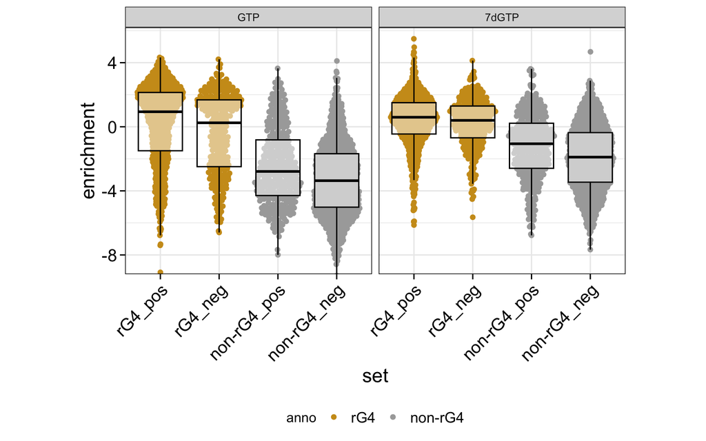

```r
constructClassificationWithG4Prediction <- readRDS(paste0(RTstopDir,
                                                          "/rds_files/constructClassificationWithG4Prediction.rds"))
Combined <- left_join(
    Combined,
    constructClassificationWithG4Prediction %>% dplyr::select(ID = constructId,
                                                              predictedG4)
)

Combined %>%
    mutate(set = case_when(anno == "rG4" & predictedG4 ~ "rG4_pos",
                           anno == "rG4" & !predictedG4 ~ "rG4_neg",
                           anno == "non-rG4" & predictedG4 ~ "non-rG4_pos",
                           anno == "non-rG4" & !predictedG4 ~ "non-rG4_neg")) %>%
    mutate(set=factor(set, levels=c("rG4_pos", "rG4_neg", "non-rG4_pos", "non-rG4_neg"))) %>%
    pivot_longer(., cols=c("normalizedBindingStrengthGTP", "normalizedBindingStrength7dGTP"),
                 names_to="facet", values_to="enrichment") %>%
    mutate(facet=factor(ifelse(facet == "normalizedBindingStrengthGTP", "GTP", "7dGTP"),
                        levels=c("GTP", "7dGTP"))) %>%
    ggplot(., aes(x=set, y=enrichment, col=anno)) +
    geom_quasirandom() +
    geom_boxplot(alpha=.5, outlier.size = -1, col="black") +
    scale_color_manual(values=c("rG4" = "goldenrod3",
                                "non-rG4" = "darkgrey")) +
    facet_wrap(~facet, ncol=2) +
    scale_y_continuous(breaks=seq(-8, 8, 4)) +
    coord_cartesian(ylim=c(-8.5, 5.5)) +
    myTheme +
    theme(aspect.ratio=1/1,
              axis.text.x = element_text(angle = 45, vjust = 1, hjust=1),
              legend.position = "bottom")
```

One can nicely see that binding strength in for the non-rG4_pos group (constructs with no measured but predicted rG4) show much weaker binding strength than constructs of the rG4_pos group (constructs with measured and predicted rG4). This observation strengthens the idea that these predictions are false positives. On the other side, the group rG4_neg (constructs with measured but not predicted rG4) show binding strength comparable to the rG4_pos group, indicating that the predictions are false negatives.

# 9 Grouping by in vivo binding site information and measured rG4 information

One final question was whether constructs with a confirmed rG4 but lacking an in vivo binding site show in vitro binding comparable to those with an in vivo binding site. If yes, this would indicate that some other RBP might prevent HNRNPH in vivo binding. Note that low in vivo expression might be a confounder as there might have been in vivo binding but signal was not strong enough due to low transcript abundance.

To test this idea, we defined the following four sets:

- in vivo binding site and measured rG4 (bound + rG4)
- in vivo binding site and no measured rG4 (bound + no rG4)
- no in vivo binding site and measured rG4 (not bound + rG4)
- no in vivo binding site and no measured rG4 (not bound + no rG4)

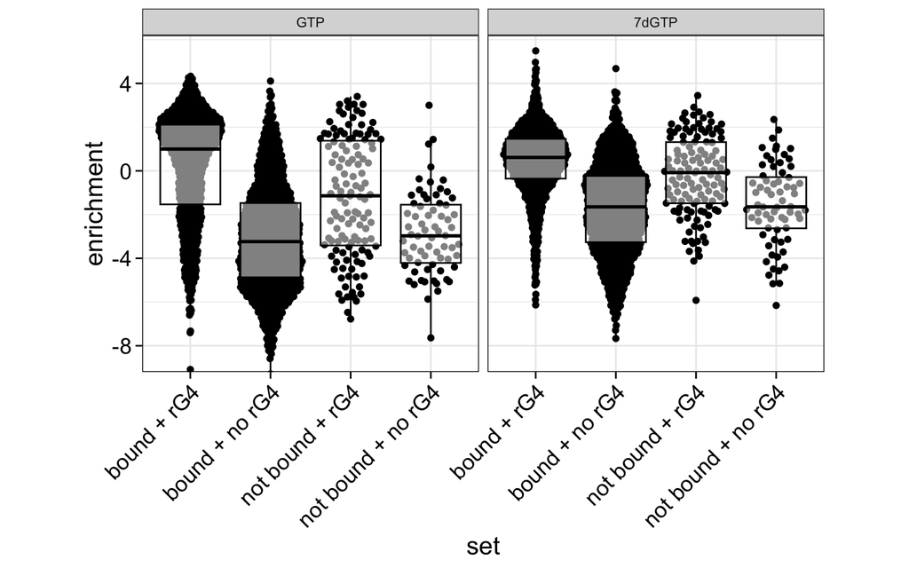

```r
binding_sites <- readRDS(paste0(iClipDir, "/rds_files/HNRNPH_binding_sites.rds"))

constructs_gr <- constructInformation %>% dplyr::select(Construct.ID, strand, coords)
constructs_gr$coords <- paste0(constructs_gr$coords,":",constructs_gr$strand)
meta <- constructs_gr %>% select(-strand)
constructs_gr <- GRanges(constructs_gr$coords)
mcols(constructs_gr) <- meta
constructs_gr$binding_site <- FALSE
constructs_gr$binding_site[findOverlaps(binding_sites, constructs_gr, type="within") %>% subjectHits %>% unique] <- TRUE


Combined <- left_join(
    Combined,
    constructs_gr %>% mcols %>% as.data.frame  %>%
        select(ID = Construct.ID, binding_site) %>% mutate(ID = as.character(ID))
) %>%
    mutate(set = case_when(binding_site == TRUE & anno == "rG4" ~ "bound + rG4",
                           binding_site == TRUE & anno == "non-rG4" ~ "bound + no rG4",
                           binding_site == FALSE & anno == "rG4" ~ "not bound + rG4",
                           binding_site == FALSE & anno == "non-rG4" ~ "not bound + no rG4",
                           TRUE ~ "not expected")) %>%
    mutate(set = factor(set, levels = c("bound + rG4", "bound + no rG4",
                                        "not bound + rG4", "not bound + no rG4")))

Combined %>%
    pivot_longer(., cols=c("normalizedBindingStrengthGTP", "normalizedBindingStrength7dGTP"),
                 names_to="facet", values_to="enrichment") %>%
    mutate(facet=factor(ifelse(facet == "normalizedBindingStrengthGTP", "GTP", "7dGTP"),
                        levels=c("GTP", "7dGTP"))) %>%
    ggplot(., aes(x=set, y=enrichment)) +
    geom_quasirandom() +
    geom_boxplot(alpha=.5, outlier.size = -1, col="black") +
    facet_wrap(~facet, ncol=2) +
    scale_y_continuous(breaks=seq(-8, 8, 4)) +
    coord_cartesian(ylim=c(-8.5, 5.5)) +
    myTheme +
    theme(aspect.ratio=1/1,
              axis.text.x = element_text(angle = 45, vjust = 1, hjust=1),
              legend.position = "bottom")
```

We can see that at least some of the constructs in the not bound + rG4 group have strong in vitro binding. These might be candidates for further exploration to check why they lack in vivo binding signal.